```python
from IPython.display import Image
```

# Data Quality - Theory

## Data Quality - Introduction

Data quality describes how good the data is for analysis. Data cleaning is the process of detecting and correcting (or removing) inaccurate or corrupt data.

This is the most important aspect of any data science and data analytics project.

An analysis cannot (or should not) be run on data that is not clean!

- In some cases the model will just break
- You will have inaccurate outcomes
- The data could skew the model

Sometimes, even if the data is "clean" the data is innately biased.

- E.x. Amazon had a controversy where it was revealed that the ML algorithm they used to assist in their recruiting efforts favored men over women
  - This was because the training data was based on previous hires, which were disproportionately male
  - Consequently, the predictions of the model always skewed towards men

Other times, the data is clean but still imbalanced (e.x. skewed towards one class over the other), but we want to work with balanced classes when possible.

We will look at ways of addressing these issues. Additionally, we will consider ways to transform and interact data.

## Common Data Cleaning Steps

Though every dataset can have its own unique issues, here are common problems that should be checked:

- Check for missing values
- Check for and remove duplicates
- Check character variables have valid values
- Check that numeric variables are within range
- Check for unique values (e.x. ID variables)
- Check for invalid dates
- Check for invalid observations
- Combine files (if needed to make a complete dataset)

How you handle each case will dependent on the problem and problem.

- E.x. For missing values -- should we just drop those values or fill them in some other way?

## Data Profiling

- We can create a summary of statistics about the data to understand the quality of the data
  - E.x. How many vaues are missing?
  - E.x. How many unique values are in a column and what is their distribution?

## Visualizations

- Visualizations can help understand data quality too
  - E.x. A scatter plot can reveal outliers

## Bias in Data Collection

- There will always be less data on minority groups
- Consequently, data collection is biased
  - Again, consider the Amazon example where their data contained more male hires than. female hires
- There could be issues just with the way data is collected
  - E.x. In FDA clinical trials, there will always be people who drop out of a trial and thus will not complete all the data that was meant to be tracked. However, we cannot ignore people who drop since there are reasons why someone would drop a trial
  - Suppose the data says that 90% of people who completed the trial were cured but 75% of all trial participants dropped out halfway)
- These issues result in **systematic bias**
  - If we make decisions based off of biased models, then we will only continue to add biased data
  - E.x. In the Amazon case, if we hire more men because of the model's recommendation then the dataset is only more biased towards men now than before if a new model were to be trained

It is always important to question how data is collected. Even if all your math is right, at the end of the day there could be issues with the data that can only be addressed by changing how data is collected.

One way of determining if there is a bias is to find the frequency of each class or feature and to understand or question where those frequencies come from with diverse stakeholders.

This concept ties into a much larger topic called **fairness**, which we will go further in-depth on in Module II.

## Imbalanced Dataset

An imbalanced dataset is one where classes are disproportionate, such as below.

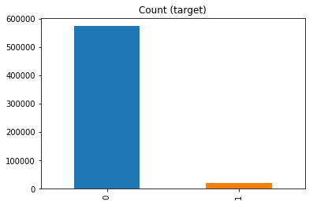

```python
Image('img/class_imbalance.png')
```

Source: Kaggle

A common trap that can happen in this case is to rely just on accuracy.

- If I were to predict 0 all the time, then I would have over 95% accuracy in this case
- This is partially why it is important to address class imbalance!

### Data Unrepresentative of Reality

What do if the data is imbalanced and unrepresentative of reality?

- Assume there is proportions bias due to the gathering method
  - In this case it is nearly mandatory to try and collect more representative data

### Data Representative of Reality

What do we do if the data is imbalanced but representative of reality? (E.x. 90% Healthy, 10% Sick)

There are four methods that can be applied:

- Undersampling
- Oversampling
- Generating synthetic data
- Adjust cost function to make misclassification of minority instances more important than misclassifcation of majority instances

**Undersampling**

- Sample only part of the points from the majority class

A popular method for this is called **near-miss**.

- In this method, when instances of two different classes are close to each other, we remove the majority instance to increase the distance between the two classes

There are three ways to do near-miss

- Select samples of majority class for which avg distances to the $k$ closest instances of the minority class is smallest
- Select samples of majority class for which avg distances to the $k$ farthest instances of the minority class is smallest
- For each minority instance, store their M-nearest neighbors. THen, select majority instances for which avg distance to the N-nearest-neighbors is the largest

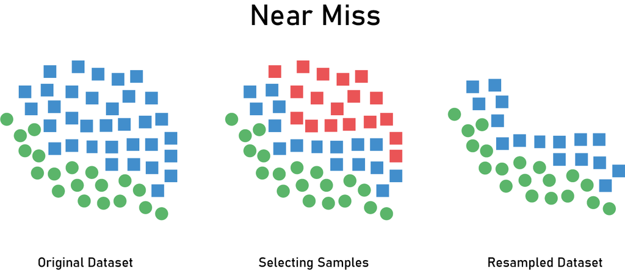

```python
Image('img/near-miss.png')
```

Source: Fritz AI

**Oversampling**

- Replicate some points in the minority class to increase its set size
- A popular method to oversample is **SMOTE**, which will be explained in section on generating synthetic data

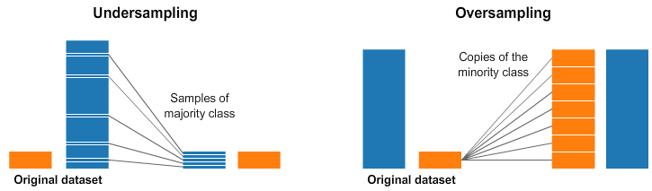

```python
Image('img/under_and_over_sampling.png')
```

Source: Kaggle

**Generating Synthetic Data**

- Create new synthetic points from the minority class
- A common way to do this is through **SMOTE**

SMOTE stands for Synthetic Minority Over-sampling Technique. A conceptual way to think about it as follows:

- Draw lines between existing minority instances
- The new, synthetic minority instances are created along these lines

```python
Image('img/smote_visual.png')
```

[figure not shown]

Source: rikunert.com

- The dots with brown borders represent the actual minority instances
- The dots with red borders represent the synthetic classes built along the Euclidean lines that connect the existing minority instances

**Adjust Cost Function** You can create a greater weight for misclassifying minority instances than majority instances

- Almost like a penalty

## Types of Data

There are two main types of data:

- **Continuous**
  - This is quantitative data where the values can be sorted (e.x. height)
- **Discrete**
  - This is qualitative data that is categorical and has no inherent ordering of values
  - E.x. {Yes, No}
  - E.x. {0, 1, 2}
  - E.x. {Monday, Tuesday, ... , Sunday}

You should understand what parts of your data are continuous or discrete.

## Data Transformations and Interactions

Sometimes variables will be more useful after a **transformation**, which is where we apply a function to a feature to change its values.

Two common data transformations are **standardization** (also known as **scaling**) and **normalization**.

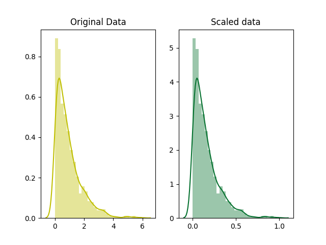

```python
Image("img/standardization.png")
```

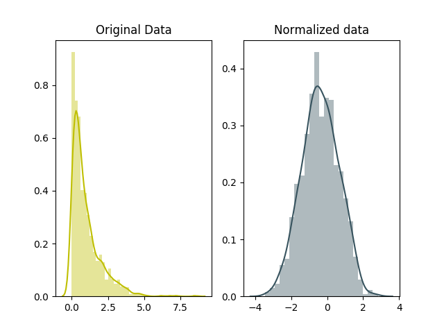

```python
Image("img/normalization.png")
```

Source: Karshit.github.io

The need for data transformations will often come through in an iterative fashion

- You will see this in the Linear Regression Case in Module II

Another factor that could necessitate the need for data transformations is the assumptions that the model you implement has

- E.x. If a model assumes a normal distribution, then make sure the features follow a normal distribution
- Always check the extent to which assumptions are met before running a model or during the evaluation of a model!
  - Assumptions will not always be perfectly met, but you should try your best

A discrete variable with $K$ classes can be represented by $K-1$ dummy binary variables. If all dummy variables are 0, the category is K.

- E.x. Suppose we have a variable for Color where the possible classes are {Red, Blue, Yellow} -- three classes total
- We can represent this as (1,0) = Red, (0,1) = Blue, (0,0) = Yellow
- This is also known as **one-hot-encoding**

An **interaction** is when we combine two features in some way to create a new variable

- E.x. $FreeTime * Age$

## More Resources

[The Ultimate Guide to Data Cleaning](https://towardsdatascience.com/the-ultimate-guide-to-data-cleaning-3969843991d4)

[Handling Imbalanced Datasets](https://towardsdatascience.com/handling-imbalanced-datasets-in-machine-learning-7a0e84220f28)

[Why Log Returns](https://quantivity.wordpress.com/2011/02/21/why-log-returns/)

[SMOTE and Near-Miss Simple](https://www.geeksforgeeks.org/ml-handling-imbalanced-data-with-smote-and-near-miss-algorithm-in-python/)

[Oversampling and Undersampling - Many Techniques](https://heartbeat.fritz.ai/resampling-to-properly-handle-imbalanced-datasets-in-machine-learning-64d82c16ceaa)